# Rstan to fit Bayesian MCMC multivariate NLME on pib, tau, and WMH%

Emily Lundt

April 24, 2025

# 1 Background

In 2021, Terry Therneau published the inaugural publication using Rstan to fit non-linear mixed effects (NLME) models.  
See https://pubmed.ncbi.nlm.nih.gov/34333107/. At that time, he was using the name ‘AFT model’ and now I more accurately call them by multivariate NLME models.

I should note that the name is not perfectly settled. More recently, Terry and Mingzhao have called them GLMEs. One could also debate which term ‘joint’ versus ‘multivariate’ is most correct.

This document was created to have everything you need in one place. That means this document should be able to run top-to-bottom, once the directory is updated to your own. For a project, best practice will be to set up a set of folders and files for each model. Often models will take hours to run, thus it is not feasible to have everything in a single file.

*Getting started at Mayo* can be slow for some. Thus, I will document some what I use in order to get Rstan to run: Rstudio via on-prem Rstudio server (node 04 or 05) and Rv4.3.2.

# 2 Purpose

In this tutorial, the Rstan package will be used to fit a Bayesian MCMC multivariate NLME model on three outcomes.

The outcome in this model are amyloid-PET SUVR, tau-PET SUVR, and WMH% of TIV.  
The data will be a simulated dataset loaded from Terry’s github page.

I will show how to extract estimates and summarize the model.

There is a section currently “in progress’ to compute the marginal covariance of individual adjustments.

The document will be a reference for myself, and can be expanded to include more concepts. It could potentially serve as a light-weight introduction to fitting these types of models.

There is a section to compute proportion over threshold curves, using two computation methods. Theoretically, these should be identical, but in my example there is a slight difference.

Future section to add would be a more complex model including both left-right covariates with units on the age scale, and up-down covariates with units on the scale of a given outcome.

In this example, I will only include left-right covariates.

# 3 Setup the data

```r
###############################
## Load packages, functions
###############################
library(tidyverse)
library(rstan)
library(brms)

## Instead of loading the knitr library, just load this function
kable <- function(...) knitr::kable(...)

###############################
## Load simulated data
###############################
# URL of the raw file on GitHub
# Must replace /blob with /raw
# github_url <- "https://github.com/therneau/AFTmodel/raw/master/fourmarker/simdata.rds"

# Local path where you want to save the file
local_path <- "./simdata.rds"

# Download the file from GitHub
# utils::download.file(url = github_url, destfile = local_path, method="auto", quiet = FALSE)

# Load the downloaded file into R
simdata <- readRDS(local_path)

###############################
## Data for these analyses
###############################

## Keep MCSA subjects having APOE genotyping
d1 <- filter(simdata, outcome %in% c('amyloid','tau','wmh'), apoemiss == 0, adrc == 0) %>%
  mutate(y.unscaled = case_when(outcome %in% 'amyloid' ~ exp(y),
                                outcome %in% 'tau' ~ exp(y),
                                outcome %in% 'wmh' ~ y*5))

## Add some useful vars
d2 <- d1 %>%
  group_by(id) %>%
  mutate(age.at.start = first(age)) %>%
  add_tally(outcome %in% 'amyloid', name='npib') %>%
  add_tally(outcome %in% 'tau', name='ntau') %>%
  add_tally(outcome %in% 'wmh', name='nwmh') %>%
  ## covars rescaled
  mutate(age10c75 = (age - 75)/10,
         educ4c14 = (educ-14)/4) %>%
  ungroup()

## Limit to the most informative subjects, having serial data
d3 <- filter(d2, npib >= 4 | ntau >=3 | nwmh >= 4)

## this step must come after filtering, as this is a fake ID
## to be passed to rstan
d4 <- d3 %>%
  ## ID variables must be a count from 1, 2, ...
  mutate(id = as.numeric(factor(id)))

d <- ungroup(d4)


###############################
# Color-blind friendly palette
###############################
col.universal <- c(Orange = "#E69F00", `Sky blue` = "#56B4E9", `Bluish green` = "#009E73",
                   Yellow = "#F0E442", Blue = "#0072B2", Vermillion = "#D55E00",
                   `Reddish purple` = "#CC79A7")

###############################
## Set up a function to plot trajectories over time
###############################
## Make it generic enough to accept
## different x's and y's
pfun2 <- function(data, ...) {
  .d <- mutate(data, color = as.character(factor(id %% 7, 0:6, col.universal)),
         alpha = ifelse(id %% 2 == 0, 1, 0.7))
  ggplot(data=.d, ...) +
    geom_line(aes(group=id, color=color, alpha=alpha)) +
    theme(legend.position='none') +
    ## Set color and alpha to value in dataset
    scale_color_identity() +
    scale_alpha_identity() +
    ## Set aspect ratio so each panel is square
    theme(aspect.ratio = 1)
}

###############################
## Set plot defaults
###############################
theme_set(theme_bw())
## update axes, borders to black. not gray
theme_update(
  axis.text = element_text(color = "black"),
  panel.border = element_rect(color = "black"))

###############################
## Setup for multiple cores
###############################
options(digits = 3, mc.cores = 4)
```

The simulated dataset was stacked per-person per-visit per-outcome.

We have limited to MCSA visits with and having APOE genotype. Subjects must have serial outcome data of 4+ pibs or 3+ taus or 4+ WMH%.

Summarize the data.

`y` is the scaled/transformed value of log amyloid, log tau, or WMH% per 5

`y.unscaled` is the unscaled value of amyloid, tau, or WMH%

```r
summarytools::dfSummary(d, plain.ascii = FALSE, style = "grid", valid.col=F,
                        tmp.img.dir = "/tmp")
```

### 3.0.1 Data Frame Summary

#### 3.0.1.1 d

**Dimensions:** 2745 x 16  
**Duplicates:** 0

| No | Variable | Stats / Values | Freqs (% of Valid) | Graph | Missing |
| --- | --- | --- | --- | --- | --- |
| 1 | id [numeric] | Mean (sd) : 135 (76.8) min < med < max: 1 < 134 < 269 IQR (CV) : 132 (0.6) | 269 distinct values |  | 0 (0.0%) |
| 2 | y [numeric] | Mean (sd) : 0.3 (0.2) min < med < max: 0 < 0.3 < 1.8 IQR (CV) : 0.2 (0.8) | 128 distinct values |  | 0 (0.0%) |
| 3 | outcome [factor] | 1. amyloid 2. tau 3. wmh 4. 1-fa | 1002 (36.5%) 573 (20.9%) 1170 (42.6%) 0 ( 0.0%) |  | 0 (0.0%) |
| 4 | age [numeric] | Mean (sd) : 75.9 (9.9) min < med < max: 51.3 < 77.3 < 101 IQR (CV) : 13.8 (0.1) | 404 distinct values |  | 0 (0.0%) |
| 5 | male [numeric] | Min : 0 Mean : 0.5 Max : 1 | 0 : 1316 (47.9%) 1 : 1429 (52.1%) |  | 0 (0.0%) |
| 6 | apoepos [numeric] | Min : 0 Mean : 0.4 Max : 1 | 0 : 1714 (62.4%) 1 : 1031 (37.6%) |  | 0 (0.0%) |
| 7 | apoemiss [numeric] | 1 distinct value | 0 : 2745 (100.0%) |  | 0 (0.0%) |
| 8 | educ [numeric] | Mean (sd) : 14.9 (2.5) min < med < max: 11 < 15 < 22 IQR (CV) : 4 (0.2) | 12 distinct values |  | 0 (0.0%) |
| 9 | adrc [numeric] | 1 distinct value | 0 : 2745 (100.0%) |  | 0 (0.0%) |
| 10 | y.unscaled [numeric] | Mean (sd) : 1.3 (0.8) min < med < max: 0 < 1.3 < 9.2 IQR (CV) : 0.6 (0.6) | 220 distinct values |  | 0 (0.0%) |
| 11 | age.at.start [numeric] | Mean (sd) : 71.5 (9) min < med < max: 51.3 < 73.1 < 91.9 IQR (CV) : 12.8 (0.1) | 187 distinct values |  | 0 (0.0%) |
| 12 | npib [integer] | Mean (sd) : 3.9 (0.9) min < med < max: 1 < 4 < 7 IQR (CV) : 1 (0.2) | 1 : 11 ( 0.4%) 2 : 117 ( 4.3%) 3 : 730 (26.6%) 4 : 1376 (50.1%) 5 : 351 (12.8%) 6 : 141 ( 5.1%) 7 : 19 ( 0.7%) |  | 0 (0.0%) |
| 13 | ntau [integer] | Mean (sd) : 2.3 (1) min < med < max: 0 < 2 < 5 IQR (CV) : 1 (0.5) | 0 : 141 ( 5.1%) 1 : 476 (17.3%) 2 : 834 (30.4%) 3 : 1071 (39.0%) 4 : 191 ( 7.0%) 5 : 32 ( 1.2%) |  | 0 (0.0%) |
| 14 | nwmh [integer] | Mean (sd) : 4.5 (0.9) min < med < max: 2 < 4 < 8 IQR (CV) : 1 (0.2) | 2 : 18 ( 0.7%) 3 : 181 ( 6.6%) 4 : 1502 (54.7%) 5 : 701 (25.5%) 6 : 275 (10.0%) 7 : 31 ( 1.1%) 8 : 37 ( 1.3%) |  | 0 (0.0%) |
| 15 | age10c75 [numeric] | Mean (sd) : 0.1 (1) min < med < max: -2.4 < 0.2 < 2.6 IQR (CV) : 1.4 (11.2) | 404 distinct values |  | 0 (0.0%) |
| 16 | educ4c14 [numeric] | Mean (sd) : 0.2 (0.6) min < med < max: -0.8 < 0.2 < 2 IQR (CV) : 1 (2.9) | 12 distinct values |  | 0 (0.0%) |

Plot a sample of trajectories.

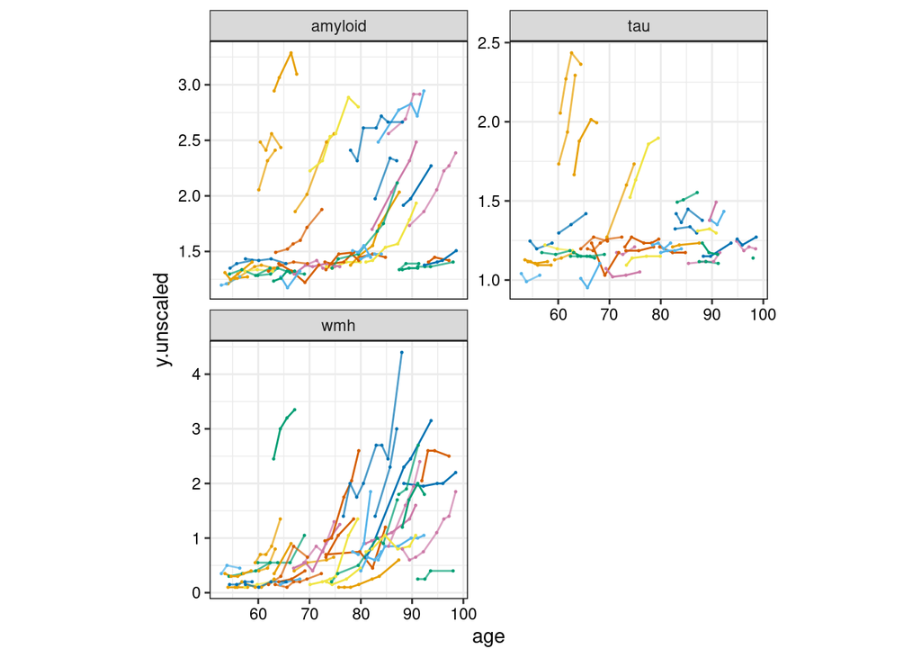

```r
set.seed(102)
ptlst <- d %>% filter(!duplicated(id)) %>%
  mutate(agedecade = cut(age.at.start, c(50,60,70,80,90,Inf))) %>%
  slice_sample(n=10, by=agedecade, weight_by=nwmh + npib + ntau**10) %>%
  pull(id)

pdat <- filter(d, id %in% ptlst)

pdat %>%
  pfun2(., mapping=aes(x=age, y=y.unscaled)) +
  geom_point(size=0.2, aes(color=color)) +
  facet_wrap(~outcome, scales='free_y', ncol=2)
```

# 4 Fit the model

Use Rstan to fit an NLME model on three outcomes.

Try to use the most recent workflow, and to include all code within this document.

## 4.1 Format the data as a list for stan

```r
## left-right covariates
x1vars <- c('male','apoepos','educ4c14')

stan.list <- list(N = nrow(d),                    ## total count obs
                  M = length(unique(d$id)),       ## total count subjects
                  P1 = length(x1vars)+1,           ## total count covars plus intercept in X1mat
                  K = length(unique(d$outcome)),  ## total count outcomes
                  ## transformations of y-values so that all outcomes
                  ## have a similar scale will improve the model fit
                  ## In this case, y is already transformed
                  y = d$y,
                  outcome = as.numeric(d$outcome),
                  outcome.label = as.character(d$outcome),
                  ## Age at y, centered and scaled more stable for rstan
                  age = d$age10c75,
                  ## left-right covariate matrix, as.matrix so stan is happy
                  ## includes intercept
                  X1 = as.matrix(cbind(1, d[,x1vars])),
                  id = d$id
                  )
```

## 4.2 Get initial values

In this example, fit an NLME model on each outcome using the meanfield algorithm of BRMS. This allows for variational inference with independent normal distributions. This model fits quickly, relative to the NUTS algorithm, and can get us a set of decent initial values for most outcomes measures.

```r
###############################
## Compute initial values
###############################

library(brms)

set.seed(240)

if(file.exists("/bigdata/bsi/neuro/s101846.adir/working/lundt/tutorials/vi-pib-tau-wmh.rda")) {
  load("/bigdata/bsi/neuro/s101846.adir/working/lundt/tutorials/vi-pib-tau-wmh.rda", verbose=T)
}
```

```
## Loading objects:
##   vi.pib
##   vi.tau
##   vi.wmh
```

```r
# Define a monotone increasing prior
myp <- prior(normal(0, 1), nlpar = "b1", lb=0) +
  prior(normal(0, 1), nlpar = "b2", lb=0) +
  prior(normal(0, 1), nlpar = "b3", lb=0) +
  prior(normal(0, 1), nlpar = "b5", lb=0)

# Define the formula
mybf <- bf(y ~ b1 + b2*x + 0.5*(b3-b2)*(x + sqrt(x^2 + b5^2)),
               b1 + b2 + b3 + b5 ~ 1,
               x ~ offset(age10c75) + male + apoepos + educ4c14 + (1 | id),
            nl = TRUE)

# Fit the variational approximation
if(!exists('vi.pib')){
vi.pib <- brm(mybf, data = filter(d, outcome=='amyloid'),
              algorithm="meanfield", tol_rel_obj = 0.01,
              iter=10000, seed=2010)
}
# NOTE: default prior worked better for pib

if(!exists('vi.tau')){
vi.tau <- brm(mybf, data = filter(d, outcome=='tau'), prior=myp,
              algorithm="meanfield", tol_rel_obj = 0.01,
              iter=10000, seed=2010)
}

if(!exists('vi.wmh')){
vi.wmh <- brm(mybf, data = filter(d, outcome=='wmh'), prior=myp,
              algorithm="meanfield", tol_rel_obj = 0.01,
              iter=10000, seed=2010)
}

par(mfrow=c(2,2))
ages <- 50:100
newd <- data.frame(age10c75 = (ages-75)/10, male = 0.5, apoepos = 0.5, educ4c14 = 0, id=9999)

pred <- predict(vi.pib, newdata = newd, allow_new_levels=T)[,'Estimate']
plot(exp(pred) ~ ages, ylab = 'pib')

pred <- predict(vi.tau, newdata = newd, allow_new_levels=T)[,'Estimate']
plot(exp(pred) ~ ages, ylab = 'tau')

pred <- predict(vi.wmh, newdata = newd, allow_new_levels=T)[,'Estimate']
plot(pred*5 ~ ages, ylab = 'wmh%')

if(!file.exists("/bigdata/bsi/neuro/s101846.adir/working/lundt/tutorials/vi-pib-tau-wmh.rda")) {
  save(vi.pib, vi.tau, vi.wmh,
       file = "/bigdata/bsi/neuro/s101846.adir/working/lundt/tutorials/vi-pib-tau-wmh.rda")
}

###############################
## Extract and format initial values to pass to stan
###############################

mods <- list(vi.pib, vi.tau, vi.wmh)
names(mods) <- c('pib','tau','wmh')

## left-right covars
(initial.beta.x1 <- sapply(mods, FUN=function(.x) fixef(.x)[5:8,'Estimate']))
```

```
##                 pib     tau     wmh
## x_Intercept -1.0031  4.0536 -1.3242
## x_male      -0.0441  0.3194 -0.1978
## x_apoepos    0.6877  1.1073 -0.0659
## x_educ4c14   0.2430 -0.0127  0.0729
```

```r
## shape parameters
(initial.shape.parm <- sapply(mods, FUN=function(.x) fixef(.x)[1:4,'Estimate']))
```

```
##                 pib     tau    wmh
## b1_Intercept 0.3737 0.10140 0.0206
## b2_Intercept 0.0394 0.00823 0.0146
## b3_Intercept 0.3276 0.02092 0.6017
## b5_Intercept 0.0232 1.87281 1.1388
```

```r
## sigma
(initial.sigma <- sapply(mods, FUN=function(.x) VarCorr(.x)[[2]][[1]][,'Estimate']))
```

```
##    pib    tau    wmh
## 0.0460 0.0426 0.0447
```

```r
## SD of random alpha
(initial.alpha.sd <- sapply(mods, FUN=function(.x) VarCorr(.x)[[1]][[1]]['x_Intercept','Estimate']))*10
```

```
##   pib   tau   wmh
## 11.52 55.30  8.08
```

```r
## Not all measures have random effect alpha for each ppt, need to add 0s
## and order the same as the data
uid.all <- unique(d$id)
uid.pib <- filter(d, outcome=='amyloid') %>% pull(id) %>% unique
uid.tau <- filter(d, outcome=='tau') %>% pull(id) %>% unique
uid.wmh <- filter(d, outcome=='wmh') %>% pull(id) %>% unique

alpha.pib <- ranef(vi.pib)[[1]][,'Estimate','x_Intercept']
alpha.pib.all <- alpha.pib[match(uid.all, uid.pib)]
alpha.pib.all[is.na(alpha.pib.all)] <- 0

alpha.tau <- ranef(vi.tau)[[1]][,'Estimate','x_Intercept']
alpha.tau.all <- alpha.tau[match(uid.all, uid.tau)]
alpha.tau.all[is.na(alpha.tau.all)] <- 0

alpha.wmh <- ranef(vi.wmh)[[1]][,'Estimate','x_Intercept']
alpha.wmh.all <- alpha.wmh[match(uid.all, uid.wmh)]
alpha.wmh.all[is.na(alpha.wmh.all)] <- 0

initial.random.effects <- cbind(alpha.pib.all, alpha.tau.all, alpha.wmh.all)
rownames(initial.random.effects) <- uid.all
head(initial.random.effects)
```

```
##   alpha.pib.all alpha.tau.all alpha.wmh.all
## 1        0.9836        -6.054         0.378
## 2        2.7911         0.000         0.401
## 3       -0.0509         0.628         0.914
## 4       -1.9732        -9.045         0.098
## 5       -0.9204        -3.030         0.430
## 6        1.0093         1.284        -0.330
```

```r
summary(initial.random.effects*10)
```

```
##  alpha.pib.all   alpha.tau.all    alpha.wmh.all
##  Min.   :-29.1   Min.   :-121.0   Min.   :-22.47
##  1st Qu.: -6.1   1st Qu.: -27.2   1st Qu.: -4.73
##  Median :  2.6   Median :  -0.2   Median : -0.44
##  Mean   :  2.8   Mean   :  -0.1   Mean   :  0.82
##  3rd Qu.: 11.5   3rd Qu.:  19.1   3rd Qu.:  5.65
##  Max.   : 35.1   Max.   : 293.6   Max.   : 30.23
```

```r
## sanity check...approx omega matrix of the pairwise correlations between random effects
cor(initial.random.effects)
```

```
##               alpha.pib.all alpha.tau.all alpha.wmh.all
## alpha.pib.all         1.000        0.4378        0.1821
## alpha.tau.all         0.438        1.0000        0.0654
## alpha.wmh.all         0.182        0.0654        1.0000
```

[figure not shown]

## 4.3 Define the stan code to fit the NLME model

In this version of the stan model code, the shape of the fit is defined by five parameters: the four estimated Bs plus the intercept in betaX1.

B[1,] is up-down shift (intercept)  
B[2,] is initial slope  
B[3,] is final slope  
B[4,] is sharpness/smoothness  
betaX1[1,] is left-right shift (intercept)

```r
## stan model code = smc
smc <- "
// Stan for a multivariate nonlinear mixed effects model
// hyper2 is for outcomes that are monotone increasing (e.g. amyloid, wmh)
// X1 = left-right covariate effects plus intercept (e.g. male, educ)


functions {
    real hyper2(real b1, real b2, real b3, real b4, real eta) {
       return(b1 + b2*eta + .5*(b3-b2)*(eta + sqrt(eta^2 + b4^2)));
    }
}

data {
  int<lower=0> M;  // number of persons (subjects)
  int<lower=0> N;  // number of observations
  int K;           // number of markers
  int P1;          // number of left-right covariates plus intercept
  real y[N];       // observed marker values
  real age[N];     // age
  matrix[N, P1] X1;  // left-right covariates
  int  id[N];      // the id index, 1,2 etc
  int  outcome[N]; // which marker for each data row
}

parameters {
   real<lower=0> sigma[K];   // residual SD
   matrix [P1,K] betaX1;     // left-right regression coefficients
   matrix [M, K] alpha;      // random left-right offsets per subject and marker
   corr_matrix[K] Omega;     // correlation
   real<lower=0> B[4,K];     // parameters of the hyperbola
   vector<lower=0>[K] atau;  // alpha SD
}
transformed parameters {
   matrix[N,K] linX1;   //  left-right linear predictors
   vector[N] eta;
   vector[N] yhat;
   row_vector[K] zero;

   zero = rep_row_vector(0,K);
   linX1 = X1*betaX1;

   for (i in 1:N){
       eta[i] = age[i] + alpha[id[i], outcome[i]] + linX1[i, outcome[i]];
       yhat[i] = hyper2(B[1, outcome[i]], // up-down shift
                        B[2, outcome[i]], // initial slope
                        B[3, outcome[i]], // final slope
                        B[4, outcome[i]], // sharpness/smoothness
                        eta[i]);          // left-right shift coef is beta[1,]
   }
}

model {
   for(k in 1:K){
     B[,k] ~ normal(0,5);
     betaX1[,k] ~ normal(0, 5); // coefs scaled as decade of age
     atau[k] ~ normal(0, 2);
     sigma[k] ~ normal(0, 1);
   }
   Omega ~ lkj_corr(2);
   matrix[K, K] Sigma_beta;  // not worth inspecting, review Omega and atau
   Sigma_beta = quad_form_diag(Omega, atau);
   for (j in 1:M) {
      alpha[j,] ~ multi_student_t(10, zero, Sigma_beta);
   }
   for (i in 1:N) {
      y[i]  ~ normal(yhat[i], sigma[outcome[i]]);
   }
}
"
```

## 4.4 Run the model

```r
## Set up to pass initial values
K <- stan.list$K # number of outcomes

## A function to generate initial values per chain
## Add a small amount of noise to each value, so chains are
## not starting at exactly the same place
init.fun <- function(chain.id=1) {
  a3 <- initial.random.effects * runif(length(initial.random.effects), 0.95, 1.05)
  omega <- round(cor(a3, use="pairwise"),2)
  list(
    betaX1  = initial.beta.x1 * runif(length(initial.beta.x1), 0.95, 1.05)
    ,alpha = a3
    ,Omega = omega
    ,atau = initial.alpha.sd * runif(length(initial.alpha.sd), 0.95, 1.05)
    ,sigma = initial.sigma * runif(length(initial.sigma), 0.95, 1.05)
    ,B = initial.shape.parm * runif(length(initial.shape.parm), 0.95,1.05)
  )
}

set.seed(1922)
n.chains <- 4
init.ll <- lapply(1:n.chains, function(chain.id) init.fun(chain.id))

## This is very slow
if(!file.exists("/bigdata/bsi/neuro/s101846.adir/working/lundt/tutorials/stan-fit-pib-tau-wmh.rda")){
stan.fit <- stan(model_code=smc,
                 data=stan.list,
                 pars = c("B","betaX1","atau","sigma","alpha","Omega"),
                 iter=2000,
                 init=init.ll,
                 thin=1,
                 seed=1922,
                 chains=4,
                 cores=4,
                 control=list(max_treedepth=15, adapt_delta=0.95)) ## same as rstanarm default
  ## too big to save out to consult directory. saved to bigdata
  save(stan.fit, file="/bigdata/bsi/neuro/s101846.adir/working/lundt/tutorials/stan-fit-pib-tau-wmh.rda")
} else load("/bigdata/bsi/neuro/s101846.adir/working/lundt/tutorials/stan-fit-pib-tau-wmh.rda")
```

## 4.5 Check posterior summary statistics and convergence diagnostics

There is good documentation of the diagnostic plots for Rstan here https://mc-stan.org/rstan/articles/index.html

Here are a few things worth checking, but this is certainly not exhaustive.

- runtime
- Rhat
- divergent transitions
- log likelihood per chain
- random sample of per-subject trajectories per chain
- mean curves per chain

```r
###############################
## Verify initial values were used
## Stan often does not throw a warning if something went wrong and
## initial values were not used.
str(stan.fit@inits[[1]])
```

```
## List of 10
##  $ sigma : num [1:3(1d)] 0.0443 0.0429 0.0455
##  $ betaX1: num [1:4, 1:3] -1.0346 -0.0423 0.6654 0.2529 4.0236 ...
##  $ alpha : num [1:269, 1:3] 0.9577 2.712 -0.0522 -1.986 -0.9211 ...
##  $ Omega : num [1:3, 1:3] 1 0.44 0.17 0.44 1 0.07 0.17 0.07 1
##  $ B     : num [1:4, 1:3] 0.3829 0.0375 0.3268 0.0235 0.0976 ...
##  $ atau  : num [1:3(1d)] 1.183 5.744 0.792
##  $ linX1 : num [1:2745, 1:3] -1.03 -1.03 -1.03 -1.03 -1.03 ...
##  $ eta   : num [1:2745(1d)] -0.4446 -0.3146 0.4931 -0.0646 0.0554 ...
##  $ yhat  : num [1:2745(1d)] 0.24 0.268 0.544 0.336 0.374 ...
##  $ zero  : num [1:3(1d)] 0 0 0
```

```r
str(init.ll[[1]])
```

```
## List of 6
##  $ betaX1: num [1:4, 1:3] -1.0346 -0.0423 0.6654 0.2529 4.0236 ...
##   ..- attr(*, "dimnames")=List of 2
##   .. ..$ : chr [1:4] "x_Intercept" "x_male" "x_apoepos" "x_educ4c14"
##   .. ..$ : chr [1:3] "pib" "tau" "wmh"
##  $ alpha : num [1:269, 1:3] 0.9577 2.712 -0.0522 -1.986 -0.9211 ...
##   ..- attr(*, "dimnames")=List of 2
##   .. ..$ : chr [1:269] "1" "2" "3" "4" ...
##   .. ..$ : chr [1:3] "alpha.pib.all" "alpha.tau.all" "alpha.wmh.all"
##  $ Omega : num [1:3, 1:3] 1 0.44 0.17 0.44 1 0.07 0.17 0.07 1
##   ..- attr(*, "dimnames")=List of 2
##   .. ..$ : chr [1:3] "alpha.pib.all" "alpha.tau.all" "alpha.wmh.all"
##   .. ..$ : chr [1:3] "alpha.pib.all" "alpha.tau.all" "alpha.wmh.all"
##  $ atau  : Named num [1:3] 1.183 5.744 0.792
##   ..- attr(*, "names")= chr [1:3] "pib" "tau" "wmh"
##  $ sigma : Named num [1:3] 0.0443 0.0429 0.0455
##   ..- attr(*, "names")= chr [1:3] "pib" "tau" "wmh"
##  $ B     : num [1:4, 1:3] 0.3829 0.0375 0.3268 0.0235 0.0976 ...
##   ..- attr(*, "dimnames")=List of 2
##   .. ..$ : chr [1:4] "b1_Intercept" "b2_Intercept" "b3_Intercept" "b5_Intercept"
##   .. ..$ : chr [1:3] "pib" "tau" "wmh"
```

```r
###############################
## Runtime, in hours
rowSums(get_elapsed_time(stan.fit))/60/60
```

```
## chain:1 chain:2 chain:3 chain:4
##   0.276   0.306   0.259   0.283
```

```r
###############################
## Get parameter summaries of stan model (ssm)
ssm <- summary(stan.fit)
## List of parameter names
nms <- rownames(ssm[[1]])
```

```r
###############################
## Review Rhat

table(cut(ssm[[1]][,'Rhat'], breaks=c(0.9,1,1.05,1.2,2,100)), useNA='always')
```

```
##
##    (0.9,1]   (1,1.05] (1.05,1.2]    (1.2,2]    (2,100]       <NA>
##         56        779         11          0          0          1
```

```r
myvars <- c(1,4,8:10)

## best Rhats
as.data.frame(ssm[[1]]) %>% arrange(Rhat) %>% select(all_of(myvars)) %>% head(20)
```

```
##                  mean   2.5%  97.5% n_eff  Rhat
## Omega[2,2]    1.00000  1.000  1.000  3877 0.999
## Omega[3,3]    1.00000  1.000  1.000  3527 0.999
## alpha[134,3] -0.63292 -1.785  0.293  4061 0.999
## alpha[12,3]   0.00938 -0.931  0.801  3033 0.999
## alpha[39,2]   1.16758 -2.586  4.952  4053 0.999
## alpha[137,2]  1.11808 -2.739  4.998  4711 0.999
## alpha[154,2]  0.68905 -2.698  4.154  5850 0.999
## alpha[216,2] -0.30264 -3.760  3.067  5160 0.999
## alpha[32,3]  -0.46227 -1.243  0.169  2156 0.999
## alpha[2,2]    2.02603 -2.213  6.345  4026 0.999
## alpha[45,1]  -0.54494 -1.980  0.829  4454 0.999
## alpha[238,3] -0.74729 -1.870  0.166  3837 0.999
## alpha[183,2] -1.43481 -5.351  2.396  5220 0.999
## alpha[96,3]  -0.11999 -1.377  0.924  3915 0.999
## alpha[129,1] -0.07746 -1.105  0.930  1634 1.000
## alpha[219,3]  0.11134 -0.885  0.979  3756 1.000
## alpha[263,2] -0.56419 -4.443  3.142  5427 1.000
## alpha[66,3]  -1.23170 -2.137 -0.525  3027 1.000
## alpha[38,3]  -0.12238 -1.120  0.720  3034 1.000
## alpha[73,2]   0.64254 -2.800  3.886  4615 1.000
```

```r
## worst Rhats
as.data.frame(ssm[[1]]) %>% arrange(desc(Rhat)) %>% select(all_of(myvars)) %>% head(20)
```

```
##                 mean    2.5%   97.5% n_eff Rhat
## alpha[127,3]  0.8232  0.5750  1.0745 127.9 1.06
## alpha[21,3]   2.4151  2.1898  2.6382 120.7 1.06
## betaX1[1,1]  -0.6257 -0.9396 -0.3228  69.3 1.06
## alpha[27,1]  -0.2527 -0.5602  0.0723  71.4 1.06
## alpha[74,3]   1.6878  1.4486  1.9283 131.1 1.05
## alpha[34,3]   2.1239  1.8964  2.3505 124.3 1.05
## betaX1[3,1]   0.5336  0.2180  0.8977  89.8 1.05
## alpha[163,1]  0.4495  0.0968  0.8111  76.4 1.05
## alpha[1,1]    0.6020  0.2774  0.9425  75.9 1.05
## alpha[265,3]  0.8312  0.5644  1.1035 148.2 1.05
## betaX1[2,2]   0.1950 -0.3630  0.7817 116.5 1.05
## alpha[114,1]  2.5501  2.2311  2.8821  80.3 1.05
## alpha[84,1]   0.2978 -0.0397  0.6379  79.5 1.05
## alpha[112,1]  1.0589  0.7465  1.3866  78.5 1.05
## alpha[11,3]   0.7486  0.5056  0.9957 143.5 1.05
## alpha[203,3]  0.9094  0.6724  1.1413 134.9 1.05
## alpha[190,1]  1.8103  1.4749  2.1597  84.7 1.05
## alpha[124,3]  1.2808  1.0247  1.5262 152.9 1.05
## alpha[40,3]  -0.2013 -0.4553  0.0617 152.3 1.05
## betaX1[2,1]   0.0215 -0.3145  0.3528  88.4 1.05
```

In a model that has converged, we want all <1.05 for a really good fit. I would be OK assessing a model where some of the alphas were >1.05, but for publication all should be <1.05.

```r
###############################
# Review log lik per chain

ll <- ssm[[2]]["lp__",c('50%','2.5%','97.5%'),]

round(ll)
```

```
##        chains
## stats   chain:1 chain:2 chain:3 chain:4
##   50%      6858    6850    6861    6847
##   2.5%     6782    6780    6784    6759
##   97.5%    6932    6926    6938    6923
```

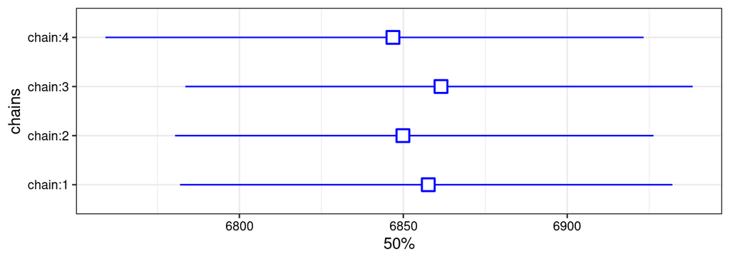

```r
t(ll) %>%
  as.data.frame %>%
  rownames_to_column(var='chains') %>%
  ggplot(aes(y=chains, x=`50%`, xmin=`2.5%`, xmax=`97.5%`)) +
  geom_pointrange(size=1, color='blue', fill='white', shape=22)
```

The log likelihood is similar in each chain, this supports that all chains have converged to the same solution.

```r
###############################
## To compare the predictions from each chain
## review a set of curves for each chain

## Have all four chains arrived at the same place?
## Have the iterations in each chain arrived at the same place?

hyper <- function(B, age) {
  ## To plot the mean curve, must match the hyper
  ## as it was called in stan
  ## So no intercept term is needed
  z <- (age - 75)/10
  yhat <-  B[1] + B[2]*z + .5*(B[3]-B[2])*(z + sqrt(z^2 + B[4]^2))
  return(yhat)
}

n.outcome <- 3 ## three outcomes
n.ipc <- stan.fit@sim$iter - stan.fit@sim$warmup  ## number iterations per chain
n.chain <- stan.fit@sim$chains   ## number of chains
n.iters <- n.ipc*n.chain
n.ppl <- stan.list$M

temp <- rstan::extract(stan.fit, pars=c("B"), permuted=FALSE, inc_warmup=F)
## sanity check...most useful for multiple outcomes
array(dimnames(temp)[[3]], dim=c(4, n.outcome))
```

```
##      [,1]     [,2]     [,3]
## [1,] "B[1,1]" "B[1,2]" "B[1,3]"
## [2,] "B[2,1]" "B[2,2]" "B[2,3]"
## [3,] "B[3,1]" "B[3,2]" "B[3,3]"
## [4,] "B[4,1]" "B[4,2]" "B[4,3]"
```

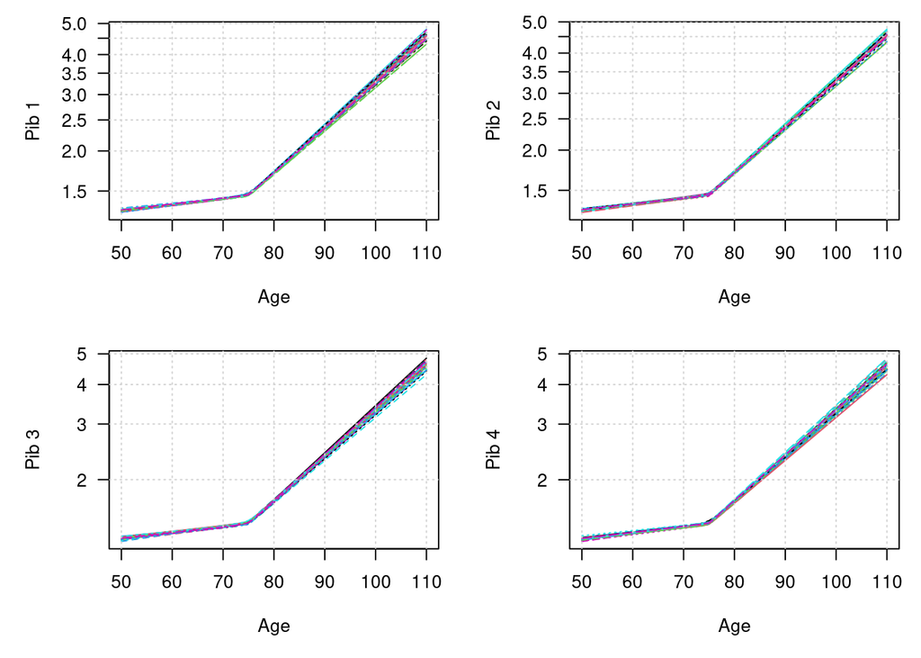

```r
## Rearrange dimensions to (iteration#, chain#, outcome, ___ )
## one dimension of temp will be the number of parameters
## In this case the four B parameters

BB <- array(temp, dim=c(n.ipc, n.chain, 4, n.outcome))

# a sampling of fits, for plotting
ii <- floor(seq(1,n.ipc,length.out=30))

xage <- 50:110

par(mfrow=c(2,2), mar=c(5,5,1,1),las=1)

ypib <- array(0, dim=c(length(xage), length(ii), n.chain))
for (chain in 1:n.chain)
  ypib[,,chain] <- sapply(ii, function(i) hyper(BB[i, chain,,1], xage))

for (i in 1:n.chain) {
  matplot(xage, exp(ypib[,,i]), type='l', log='y',
          xlab="Age", ylab = paste("Pib", i))
  grid()
}
```

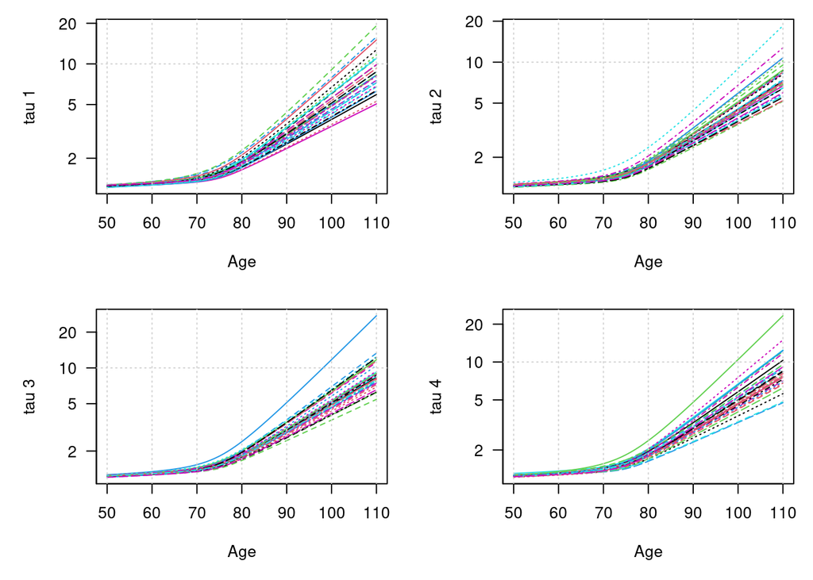

```r
ytau <- array(0, dim=c(length(xage), length(ii), n.chain))
for (chain in 1:n.chain)
  ytau[,,chain] <- sapply(ii, function(i) hyper(BB[i, chain,,2], xage))

for (i in 1:n.chain) {
  matplot(xage, exp(ytau[,,i]), type='l', log='y',
          xlab="Age", ylab = paste("tau", i))
  grid()
}
```

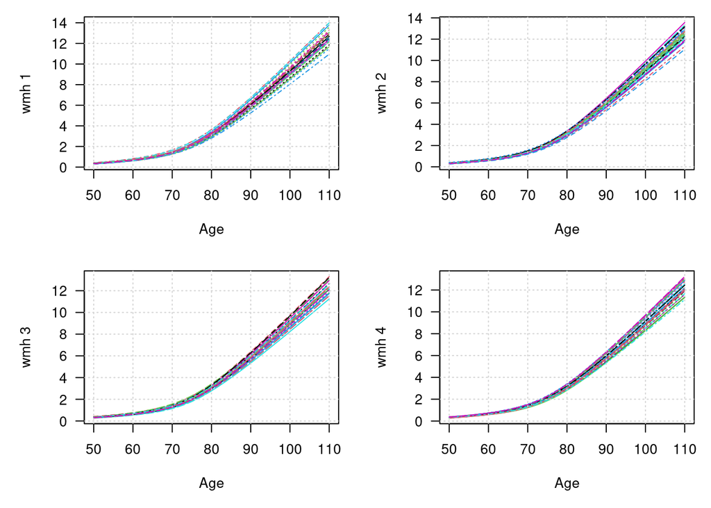

```r
ywmh <- array(0, dim=c(length(xage), length(ii), n.chain))
for (chain in 1:n.chain)
  ywmh[,,chain] <- sapply(ii, function(i) hyper(BB[i, chain,,3], xage))

for (i in 1:n.chain) {
  matplot(xage, ywmh[,,i]*5, type='l',
          xlab="Age", ylab = paste("wmh", i))
  grid()
}
```

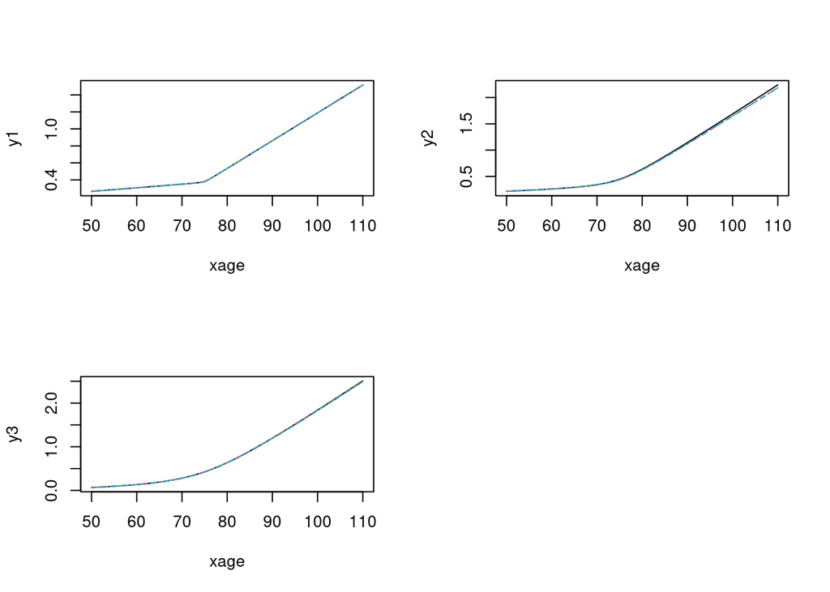

```r
###############################
## Plot mean curve per chain

## Might be easier to assess whether all four chains arrived at
## the same mean curve than looking at curves from random sample iterations

xage <- 50:110
y1 <- array(0, dim=c(length(xage), n.ipc, n.chain))
for (chain in 1:n.chain)
  y1[,,chain] <- sapply(1:n.ipc, function(i) hyper(BB[i, chain,,1], xage))
y1 <- apply(y1, c(1,3), mean)

y2 <- array(0, dim=c(length(xage), n.ipc, n.chain))
for (chain in 1:n.chain)
  y2[,,chain] <- sapply(1:n.ipc, function(i) hyper(BB[i, chain,,2], xage))
y2 <- apply(y2, c(1,3), mean)

y3 <- array(0, dim=c(length(xage), n.ipc, n.chain))
for (chain in 1:n.chain)
  y3[,,chain] <- sapply(1:n.ipc, function(i) hyper(BB[i, chain,,3], xage))
y3 <- apply(y3, c(1,3), mean)

par(mfrow=c(2,2))
matplot(xage, y1, type='l')
matplot(xage, y2, type='l')
matplot(xage, y3, type='l')
```

All chains are nearly identical and plotted on top of each other. This model has converged.

Recall that the curves based on the per-chain means may differ from each other if the model has not converged. The overall mean model will be an average of the chains, so the overall curve would likely look different from the per-chain curves in the situation where we have not reached convergence.

# 5 Review individual random effects (alphas)

Individual random effects are per-person per-outcome left-right shifts on the age scale denoted by alpha. Thus alpha_{11} would be the estimated value of the random effect for the person `1` and outcome `1`.

Because this is a Bayesian model, we want to extract the estimated random effect for each person by outcome. And then we would like to look at the pairwise scatterplots. This will help us get a sense of whether subjects who tend to have earlier amyloid deposition, also tend to have earlier tau deposition.

```r
alphas <- ssm$summary[grep('alpha',nms,value=T),] %>%
  data.frame() %>%
  ## mult by 10 to convert to years, not decades
  mutate(across(everything(),~.*10)) %>%
  rownames_to_column() %>%
  separate(rowname, into=c('term','id','outcome')) %>%
  mutate(outcome = factor(outcome, levels=1:3, labels=c('pib','tau','wmh')),
         id = as.numeric(id))
head(alphas)
```

```
##    term id outcome   mean se_mean    sd  X2.5.   X25.   X50.   X75. X97.5. n_eff  Rhat
## 1 alpha  1     pib   6.02  0.1940  1.69   2.77   4.86   6.01   7.15   9.42   759 10.51
## 2 alpha  1     tau -32.84  0.3006 10.35 -55.61 -39.22 -32.33 -25.79 -14.01 11853 10.05
## 3 alpha  1     wmh   3.84  0.0989  1.19   1.64   3.01   3.82   4.63   6.24  1445 10.41
## 4 alpha  2     pib  24.35  0.1782  1.86  20.85  23.05  24.26  25.66  28.01  1094 10.36
## 5 alpha  2     tau  20.26  0.3440 21.83 -22.13   6.06  20.37  34.64  63.45 40259  9.99
## 6 alpha  2     wmh   4.21  0.0803  3.02  -2.36   2.38   4.50   6.26   9.43 14154 10.01
```

```r
## plotting dataset
pdat <- select(alphas, id, outcome, mean) %>%
  pivot_wider(names_from=outcome, values_from=mean, names_prefix='alpha.') %>%
  ## Set some alphas to missing
  ## All ppt get an estimated alpha, regardless of having data for that outcome
  ## We do not want to look at alphas for ppts w/o observed values of the outcome
  ## merge in number of scans per person, and blank if 0
  left_join(filter(d, !duplicated(id)) %>% select(id, npib, ntau, nwmh)) %>%
  mutate(alpha.pib = ifelse(npib == 0,NA,alpha.pib),
         alpha.tau = ifelse(ntau == 0,NA,alpha.tau),
         alpha.wmh = ifelse(nwmh == 0,NA,alpha.wmh))
pdat
```

```
## # A tibble: 269 × 7
##       id alpha.pib alpha.tau alpha.wmh  npib  ntau  nwmh
##    <dbl>     <dbl>     <dbl>     <dbl> <int> <int> <int>
##  1     1      6.02   -32.8        3.84     3     1     6
##  2     2     24.3     NA          4.21     3     0     4
##  3     3     -1.03     5.47       9.24     2     2     4
##  4     4    -26.3    -53.7        1.14     2     1     4
##  5     5    -11.3    -16.0        3.50     2     1     4
##  6     6      8.38    14.8       -3.76     4     3     4
##  7     7     -2.64   -28.6       14.9      3     3     3
##  8     8      7.05    24.8       13.0      4     2     4
##  9     9     -8.65    -0.189      2.68     4     3     4
## 10    10     -9.48    -1.83      -7.28     4     1     4
## # ℹ 259 more rows
```

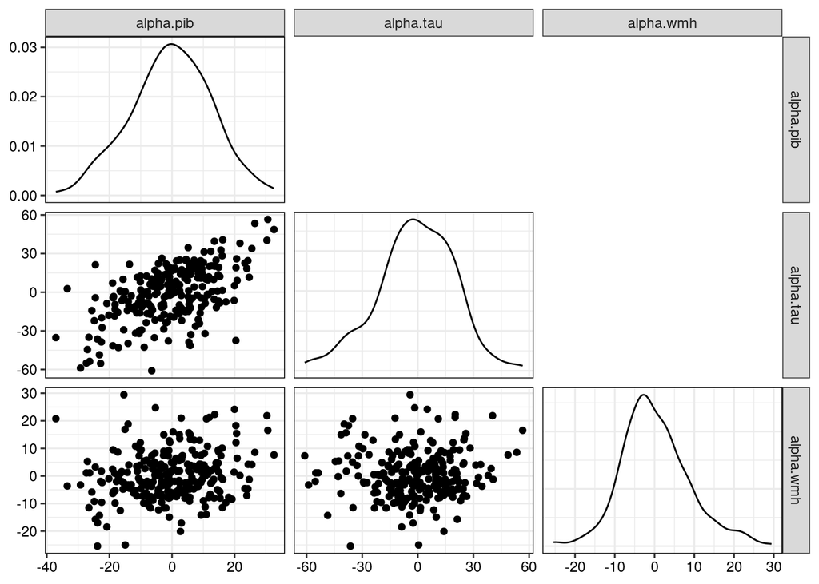

```r
GGally::ggpairs(select(pdat, contains('alpha')),
                upper  = list(continuous = "blank"))
```

```r
## For some of the computations in the following sections,
## we will need all parameters from all iterations

## Get all iterations
B.all <- rstan::extract(stan.fit, pars="B")[[1]]
beta.all <- rstan::extract(stan.fit, pars="betaX1")[[1]]
alpha.all <- rstan::extract(stan.fit, pars="alpha")[[1]]
omega.all <- rstan::extract(stan.fit, pars="Omega")[[1]]
sigma.all <- rstan::extract(stan.fit, pars='sigma')[[1]]
alpha.sd.all <- rstan::extract(stan.fit, pars='atau')[[1]]
```

# 6 Covariance of individual effects for WMH given pib and tau

We want the distribution of alpha[i,wmh] | alpha[i,PiB], alpha[i,TauPET].

Computations must occur per-iteration before averaging.

```r
## Build Sigma, for each iteration, the variance-covariance matrix for three alphas
vcov.all <- array(0, dim = dim(omega.all))
for(i in 1:n.iters) {
  sd1 <- alpha.sd.all[i,1]
  sd2 <- alpha.sd.all[i,2]
  sd3 <- alpha.sd.all[i,3]
  cor12 <- omega.all[i,1,2]
  cor13 <- omega.all[i,1,3]
  cor23 <- omega.all[i,2,3]
  cov12 <- cor12 * sd1 * sd2
  cov13 <- cor13 * sd1 * sd3
  cov23 <- cor23 * sd2 * sd3
  vcov.all[i,,] <- rbind(c(sd1^2, cov12, cov13),
                         c(cov12, sd2^2, cov23),
                         c(cov13, cov23, sd3^2))
}

#
# ###############################
# ## Sanity check of var-covar matrix
# ## code by Stephen Weigand
# ###############################
# mat <- as.matrix(stan.fit)
# mat.use <- mat[, c(grep("Omega", colnames(mat), value = TRUE),
#                    grep("atau", colnames(mat), value = TRUE))]
# # mat <- rstan::extract(stan.fit, permuted = F)
#
# ## Build up the variance covariance matrix of three alphas
# build.Sigma <- function(params, which.vars = 1:3) {
#     sd1 <- params[sprintf("atau[%d]", which.vars[1])]
#     sd2 <- params[sprintf("atau[%d]", which.vars[2])]
#     sd3 <- params[sprintf("atau[%d]", which.vars[3])]
#     cor12 <- params[sprintf("Omega[%d,%d]", which.vars[1], which.vars[2])]
#     cor13 <- params[sprintf("Omega[%d,%d]", which.vars[1], which.vars[3])]
#     cor23 <- params[sprintf("Omega[%d,%d]", which.vars[2], which.vars[3])]
#     cov12 <- cor12 * sd1 * sd2
#     cov13 <- cor13 * sd1 * sd3
#     cov23 <- cor23 * sd2 * sd3
#     rbind(c(sd1^2, cov12, cov13),
#           c(cov12, sd2^2, cov23),
#           c(cov13, cov23, sd3^2))
# }
#
# ## not even the first iteration matches. blech.
# i <- 1
# vcov.all[i,,]
# build.Sigma(mat.use[i, ], which.vars = 1:3)
# alpha.sd.all[i,]
# nm <- c("atau[1]","atau[2]","atau[3]")
# mat.use[i,nm]
#
#
# # NOTE: iterations are numbered differently when useing as.matrix() vs extract()
# # so hard to check his vs mine. annoying.
#
# # as.matrix(stan.fit)[1:2, nm]
# # rstan::extract(stan.fit, permuted = F)[1,,nm]
# # rstan::extract(stan.fit, permuted = T)$atau[1:2,]
# # rstan::extract(stan.fit, pars='atau')$atau[1:2,]
# # rstan::extract(stan.fit, pars='atau',permuted=FALSE)[1:2,1:4,1:3]
# # rstan::extract(stan.fit, pars='atau',permuted=TRUE)$atau[1:2,]
# # rstan::extract(stan.fit, pars='atau',permuted=TRUE)$atau[1001:1002,]
# # rstan::extract(stan.fit, pars='atau',permuted=TRUE)$atau[2001:2002,]
# # rstan::extract(stan.fit, pars='atau',permuted=TRUE)$atau[3001:3002,]
```

I think we can compute the conditional variance of WMH given pib and tau from the 3x3 variance-covariance matrix.  
We will need to use the Schur complement to do this.

```r
## compute the conditional variance of alpha wmh given pib and tau

###############################
## For a single iteration
###############################

i <- 7

## 1. partition the covariance matrix into blocks

## covariance matrix of pib and tau
(Sigma11 <- vcov.all[i,1:2,1:2])
```

```
##      [,1] [,2]
## [1,] 1.55 1.44
## [2,] 1.44 5.53
```

```r
## cross-covariances
(Sigma12 <- c(vcov.all[i,1,3], vcov.all[i,2,3]))
```

```
## [1]  0.127 -0.231
```

```r
(Sigma21 <- rev(Sigma12))
```

```
## [1] -0.231  0.127
```

```r
## variance of wmh, unconditional
(Sigma22 <- vcov.all[i,3,3])
```

```
## [1] 0.691
```

```r
## sanity check...should be same
Sigma22; alpha.sd.all[i,3]^2
```

```
## [1] 0.691
```

```
## [1] 0.691
```

```r
## 2. compute the conditional variance of wmh given pib and tau
(conditional_variance <- Sigma22 - Sigma12 %*% solve(Sigma11) %*% Sigma21)
```

```
##       [,1]
## [1,] 0.739
```

```r
## 3. R^2, percent variation explained

## R^2 is conditional variance of alpha wmh / divided by the marginal variance of alpha wmh
## R^2 is the proportion of conditional var div by total var of y
1 - conditional_variance / Sigma22
```

```
##         [,1]
## [1,] -0.0685
```

```r
(1 - conditional_variance / Sigma22) * 100
```

```
##       [,1]
## [1,] -6.85
```

The conditional correlation is weak, as is expected. WMH was not strongly correlated to either of PiB nor tau, so we expected a weak correlation of WMH|PiB,Tau

```r
###############################
## For each iteration
###############################

rsq <- rep(0, n.iters)
pve <- rep(0, n.iters)
for(i in 1:n.iters){
  Sigma11 <- vcov.all[i,1:2,1:2]
  Sigma12 <- vcov.all[i,1:2,3]
  Sigma22 <- vcov.all[i,3,3]
  .cv <- Sigma22 - rev(Sigma12) %*% solve(Sigma11) %*% Sigma12
  rsq[i] <- 1 - .cv / Sigma22
  pve[i] <- (1 - .cv / Sigma22) * 100
}

summary(rsq)
```

```
##    Min. 1st Qu.  Median    Mean 3rd Qu.    Max.
## -0.1819 -0.0285 -0.0054 -0.0070  0.0152  0.1640
```

```r
summary(pve)
```

```
##    Min. 1st Qu.  Median    Mean 3rd Qu.    Max.
##  -18.19   -2.85   -0.54   -0.70    1.52   16.40
```

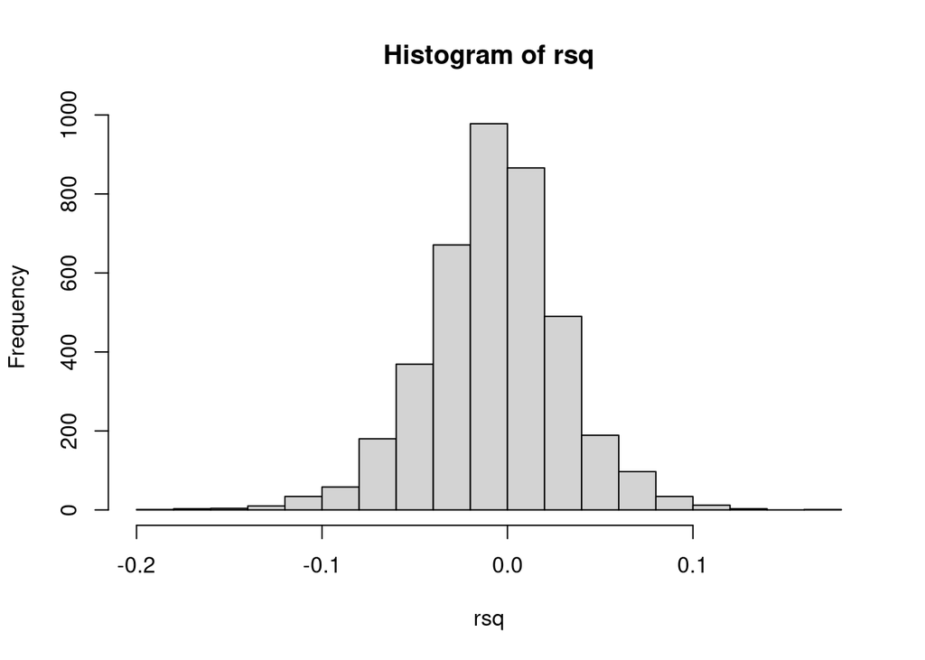

```r
hist(rsq)
```

# 7 Proportion over threshold

*Cut points*

There are different approaches for selecting cut-points for each measure. Here are a few ides:

1. Published or established cut-points
2. Young normal mean+kSD: Use distribution of the outcome from a young-normal MCSA sample that has all outcomes measures of interest. Cut-point computed as mean + kSD from the normals.
3. Mixture modeling: extract the mean and SD from ‘normal/healthy’ cluster using mixture modeling. Cut-point computed as mean + kSD from the normals.

For this report, use:

- Abnormal amyloid PET meta-ROI (PIB_CENTILOID >= 25 or PIB_SUVR >= 1.52)
- Abnormal tau PET meta-ROI (TAU_SUVR ≥ 1.29)
- Abnormal Schwarz GE WMH% (WMHPCTTIV >= 1.62)

This model was fit on simulated data.  
The raw data was estimated using Schwarz WMH algorithm and GE-only scans. So this may be an older cut-point, but that seems OK.

## 7.1 CDF of offsets

The “CDF of offsets method” is computationally faster to compute proportion over threshold curves vs CDF of outcome (formerly brute-force).

Terry came up with this idea that makes use of the CDF of the offsets.

This method will work for outcomes with left-right shifts and covariates. This method will NOT work for outcomes additionally having up-down shifts and covariates. (e.g. cognition)

We will need to eventually do this computation for all iterations, and on all people, but the way this code works can be opaque to me.

### 7.1.1 Example for amyloid and a single iteration

To understand it better, start by walking through the steps on just amyloid and for a single iteration.

1. Get age at which cut-point crosses target curve

Convert cut-point to age-scale using the overall mean curve.

```r
## A set of ages was defined above
## centered and scaled to match the data passed to the model
xage.sc <- (xage-75)/10

## amyloid-pet SUVR cut-point, on log-scale
cut.pib <- log(1.52)

## the mean estimated B parameters that define the shape of they amyloid-PET hyperbola
B.pib.mean <- c(0.3700, 0.0424, 0.3276, 0.0664)

## Exponentiation to undo log-scale
## predictions at each year of age
## approx converts to age-scale cut-point
.ycut.pib <- approx(hyper(B.pib.mean, xage), xage.sc, cut.pib)$y
```

.ycut corresponds to 1.52 SUVR.

Since this is relative to the target curve, I suppose this is the “adjusted amyloid age cut-point”.

.ycut is centered and scaled, as age was in the model. Convert to age in years: 76.417

2. Get linear predictor ‘covar adj offsets’ as matrix for a single iteration.

```r
## Matrix of covariate values, one row per person
aX <- stan.list$X[!duplicated(stan.list$id),]

beta.pib1 <- beta.all[1,,1]
alpha.pib1 <- alpha.all[1,,1]
offset.pib1 <- aX %*% beta.pib1 + alpha.pib1
```

3. Compute a set of x (age) and y (proportion) values which can be used to produce a curve of the predicted proportion over a given threshold at each age

Let offset = aX * beta + alpha = covar adjusted offset. Then anyone for whom age + offset > .ycut will be above the 1.52 line (.ycut).

At a target age of x, then, all subjects with x+offset > ycut, or x > ycut - offset, will be predicted to progress.

If 20% of the offsets are > 15y, say, then 20% of the subjects are predicted to progress by age ycut-15y. Now apply the CDF for offset, which is the proportion in the population having up to but not more than the given value. This is the inverse of what we ultimately want to plot.

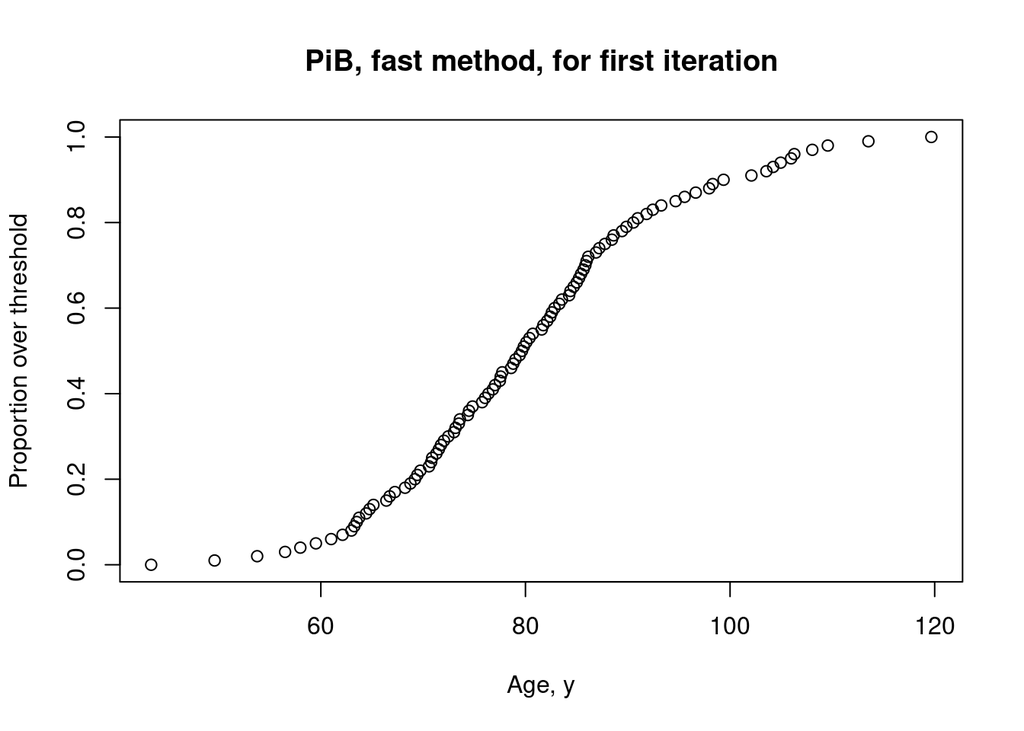

Figure 7.1: .

```r
## Set of desired proportions
yy <- 0:100/100

## Summarize the distribution of the "covariate adjusted offsets"
offset.pib.cdf1 <- quantile(offset.pib1, yy)

## Then subtract to convert to the age-scale
## This gets us a set of ages corresponding the proportions
xx <- .ycut.pib - offset.pib.cdf1

## Plot the proportion over threshold for pib
## Quantile gives proportion below
## but we want proportion above, hence 1-yy
## Converge to age in years before plotting
par(mfrow=c(1,1))
plot(xx*10+75, (1-yy), xlab='Age, y', ylab='Proportion over threshold', main = 'PiB, fast method, for first iteration')
```

**As a check**, compute the adjusted amyloid age using offset and current age.

```r
###############################
## offset + current age = adj pib age = eta
adj.pib.age <- (offset.pib1[stan.list$id] + stan.list$age)[stan.list$outcome==1]*10+75
summary(adj.pib.age)
```

```
##    Min. 1st Qu.  Median    Mean 3rd Qu.    Max.
##    36.4    62.0    72.3    72.0    84.0   104.7
```

**Interpretation of the proportion:**

```r
(pp <- sum(((70-75)/10 + offset.pib1) > .ycut.pib)/length(offset.pib1) * 100)
```

```
## [1] 22.3
```

Assuming everyone in our sample lived to age 70, then we would expect 22.305% of those subjects would have abnormal amyloid, for the first iteration.

```r
(pp <- sum(((80-75)/10 + offset.pib1) > .ycut.pib)/length(offset.pib1) * 100)
```

```
## [1] 51.7
```

Assuming everyone in our sample lived to age 80, then we would expect that 51.673% of those subjects would have abnormal amyloid.

*Tip:* Consider for each outcome the direction of abnormality, and how that impacts the calculations. High is abnormal for PiB, but low is abnormal for cognition or abeta ratio.

### 7.1.2 All iterations and outcomes

Now, let’s apply this method over all iterations, and all outcomes.

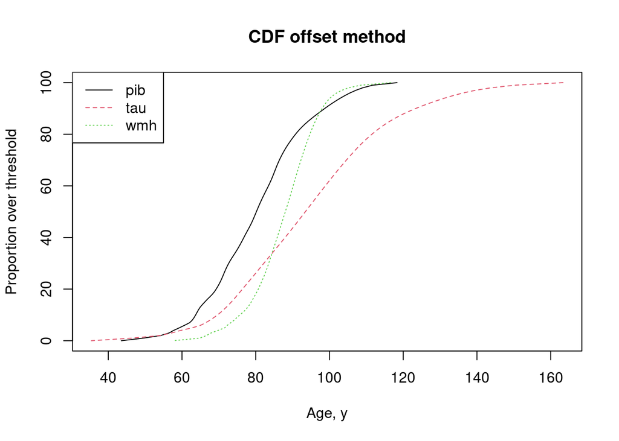

Figure 7.2: .

```r
## Above, we already have defined most of what we need:
## beta.all: estimated covariate effects for each iteration and outcome
## alpha.all: individual adjustments for all iterations, ppl, and outcomes
## aX: matrix of per-subject covariate values
## yy: vector of proportions of interest

##  .ycut for each outcome:
B.mean <- apply(B.all, 2:3, mean)
.ycut <- c(approx(hyper(B.mean[,1], xage), xage.sc, log(1.52))$y,
           approx(hyper(B.mean[,2], xage), xage.sc, log(1.29))$y,
           approx(hyper(B.mean[,3], xage), xage.sc, 1.62/5)$y)

## empty matrix for predicted ages
xx.all <- array(0, dim = c(n.iters, n.outcome, length(yy)),
                 dimnames = list('iteration'=1:n.iters,
                                 'outcome'=1:n.outcome,
                                 'prop'=1:length(yy)))
for(i in 1:n.iters) {
  for(o in 1:n.outcome) {
    ## 'covariate adjusted left-right offset'
    .offset <- alpha.all[i,,o] + aX %*% beta.all[i,,o]
    ## Summarize the distribution of offsets
    .cdf <- quantile(.offset, yy)
    ## subtract to get a set of ages (in decades)
    ## corresponding the proportions
    xx.all[i,o,] <- .ycut[o] - .cdf
  }}

xx.pib.mean <- apply(xx.all[,1,], 2, mean)
xx.tau.mean <- apply(xx.all[,2,], 2, mean)
xx.wmh.mean <- apply(xx.all[,3,], 2, mean)

.p <- c(0.5,0.025,0.975)
xx.pib.ci <- apply(xx.all[,1,], 2, quantile, probs=.p)
xx.tau.ci <- apply(xx.all[,2,], 2, quantile, probs=.p)
xx.wmh.ci <- apply(xx.all[,3,], 2, quantile, probs=.p)

## Plot the proportion over threshold for pib
## Quantile gives proportion below
## but we want proportion above, hence 1-yy
## Converge to age in years before plotting
matplot(cbind(xx.pib.mean, xx.tau.mean, xx.wmh.mean)*10+75,
        (1-yy)*100, type='l', ylim=c(0,100),
        xlab='Age, y', ylab='Proportion over threshold', main = 'CDF offset method')
legend('topleft',lty=1:3,col=1:3,legend=c('pib','tau','wmh'))
```

## 7.2 Compute yhat for a set of ages, the CDF of outcomes method

For outcomes like cognition with up-down covariates or individual adjustments, I don’t think we can use the computationally faster method.

Show how to do this computation without using the “CDF of the offsets” trick above.

There may be a smarter way to program this. But my approach was to compute yhat for each iteration, each subjects, for each potential age.

An update was made on 04/2025 to the program, to add epsilon(e_ij) after evaluating the `hyper()` function. In the offset-CDF method, we can ignore this residual noise, or measurement error. But in the outcome-CDF method, which is meant to mimic the full data-generating process more closely, it’s correct (and important) to add the epsilon back.

```r
## Get predicted yhat for all iterations, all subjects, and a set of ages for each person.
## This will be a very large object.

## Because this section can be slow; load summaries of the yhats
## Only run the first few computations below when
## this file does not exist.
.f <- "/bigdata/bsi/neuro/s101846.adir/working/lundt/tutorials/summaries-of-outcome-CDF-pct-abnormal-pib-tau-wmh.rda"
if(file.exists(.f)) {
  load(.f)
  } else {
  ###############################
  # 1. compute offset per iteration, per person, per outcome

  ## Calculate linear predictor 'covariate adjusted left-right offset'
  ## in decades
  ## (per iter, per person, per outcome)
  offset.all <- array(0, dim = c(n.iters, n.ppl, n.outcome),
                   dimnames = list('iteration'=1:n.iters,
                                   'id'=1:n.ppl,
                                   'outcome'=1:n.outcome))
  for(i in 1:n.iters) {
    for(o in 1:3) {
      offset.all[i,,o] <- alpha.all[i,,o] + aX[,] %*% beta.all[i,,o]
    }}

  ###############################
  # 2. compute eta = offset + each age of interest

  ## Add a 4th dimension for ages
  eta.all <- array(0, dim = c(n.iters, n.ppl, n.outcome, length(xage)),
                   dimnames = list('iteration'=1:n.iters,
                                   'id'=1:n.ppl,
                                   'outcome'=1:n.outcome,
                                   'age'=1:length(xage)))
  for(a in 1:length(xage)) {
    eta.all[,,,a] <- offset.all + xage.sc[a]
  }

  ###############################
  # 3. get predicted outcome, yhat
  set.seed(310)
  yhat.all <- array(0, dim = c(n.iters, n.ppl, n.outcome, length(xage)),
                   dimnames = list('iteration'=1:n.iters,
                                   'id'=1:n.ppl,
                                   'outcome'=1:n.outcome,
                                   'age'=1:length(xage)))
  for(i in 1:n.iters){
    for(o in 1:n.outcome){
      for(a in 1:length(xage)) {
        yhat.all[i,,o,a] <- hyper(B = B.all[i,,o],
                                  ## Recall, set up to accept age in years
                                  age = eta.all[i,,o,a]*10+75 ) +
          ## 20250423 - add measurement error
          ## Take a random draw from N(0, sigma-per-iteration)
          ## since we average over all people, it should be OK that
          ## we are not taking the specific epsilon per-person which
          ## technically was estimated, but not saved out.
          rnorm(n=n.ppl, mean=0, sd = sigma.all[i,o])
      }}}

  ###############################
  # 4. for each outcome, summarize proportion over cut-point per iteration and at each age

  pct.ab.pib.all <- apply(yhat.all[,,1,] > log(1.52), c(1,3), sum)/n.ppl*100
  pct.ab.pib.mean <- apply(pct.ab.pib.all, 2, mean)

  pct.ab.tau.all <- apply(yhat.all[,,2,] > log(1.29), c(1,3), sum)/n.ppl*100
  pct.ab.tau.mean <- apply(pct.ab.tau.all, 2, mean)

  pct.ab.wmh.all <- apply(yhat.all[,,3,] > 1.62/5, c(1,3), sum)/n.ppl*100
  pct.ab.wmh.mean <- apply(pct.ab.wmh.all, 2, mean)


  ###############################
  # 5. for each outcome, summarize quantiles at each age (median, credible interval)
  .p <- c(0.5, 0.025, 0.975)
  pct.ab.pib.ci <- apply(pct.ab.pib.all, 2, quantile, probs = .p)

  # ## sanity check...mean and median should be similar
  # summary(pct.ab.pib.mean)
  # summary(pct.ab.pib.ci['50%',])
  #
  # summary(pct.ab.pib.ci['2.5%',])
  # summary(pct.ab.pib.ci['97.5%',])

  pct.ab.tau.ci <- apply(pct.ab.tau.all, 2, quantile, probs = .p)

  pct.ab.wmh.ci <- apply(pct.ab.wmh.all, 2, quantile, probs = .p)

  ## Save the percent abnormal summaries
  save(pct.ab.pib.mean, pct.ab.pib.ci,
       pct.ab.tau.mean, pct.ab.tau.ci,
       pct.ab.wmh.mean, pct.ab.wmh.ci,
       file = .f)

}
```

Show all outcomes together

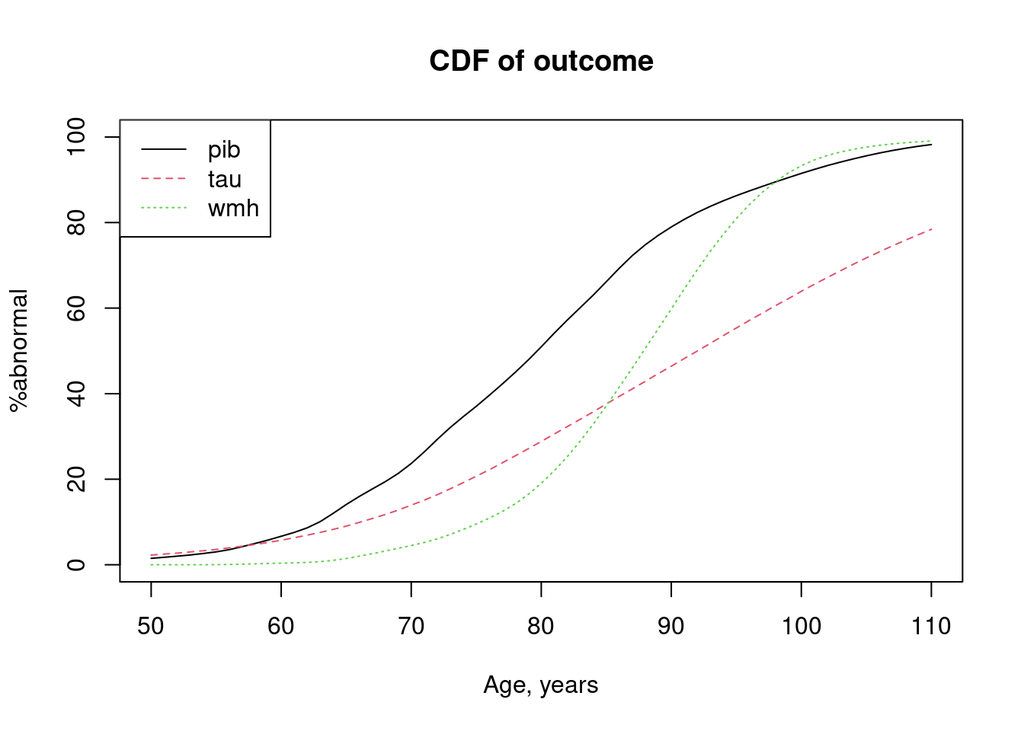

Figure 7.3: .

```r
matplot(y = cbind(pct.ab.pib.mean, pct.ab.tau.mean, pct.ab.wmh.mean),
        x = xage, type = 'l', main='CDF of outcome', ylim=c(0,100),
        xlab = 'Age, years', ylab = '%abnormal')
legend('topleft',lty=1:3,col=1:3,legend=c('pib','tau','wmh'))
```

## 7.3 Compare methods

We expect the methods to be quite similar, if not identical.

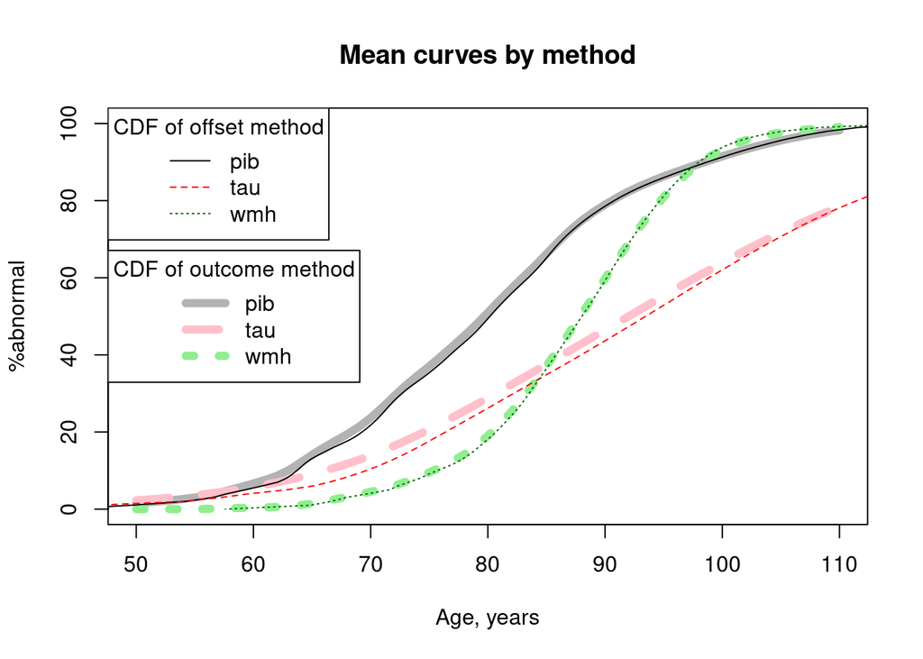

Figure 7.4: .

```r
## CDF of outcome colors per pib, tau, wmh
.colb <- c('gray70','pink','lightgreen')

## CDF of offset colors per pib, tau, wmh
.colc <- c('black','red','darkgreen')

matplot(y = cbind(pct.ab.pib.mean, pct.ab.tau.mean, pct.ab.wmh.mean),
        x = xage, type = 'l', ylim=c(0,100),
        xlab = 'Age, years', ylab = '%abnormal',
        main = 'Mean curves by method',
        lwd=6, col= .colb)
matlines(y = (1-yy)*100,
         x = cbind(xx.pib.mean, xx.tau.mean, xx.wmh.mean)*10+75, col=.colc)
legend('topleft',lty=1:3,col=.colc,legend=c('pib','tau','wmh'), title='CDF of offset method')
legend('left',lty=1:3,col=.colb,legend=c('pib','tau','wmh'),lwd=6, title='CDF of outcome method')
```

For tau, the estimated proportions do not appear identical at all ages. Take age 80, the proportion by the CDF of offset method is slightly less vs outcome. That’s interesting and might be worth having a PhD think about this more.  
But, these are similar enough that I am OK with reporting the results using either computational method.

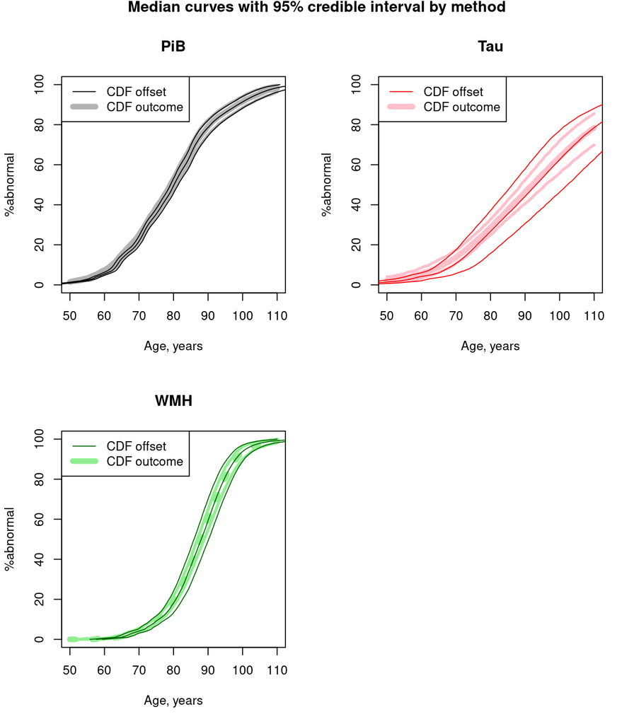

Figure 7.5: .

```r
par(mfrow=c(2,2), oma=c(0,0,1,0))
matplot(y = t(pct.ab.pib.ci),
        x = xage, type = 'l', ylim=c(0,100),
        xlab = 'Age, years', ylab = '%abnormal', main='PiB',
        lwd=c(6,3,3), col= .colb[1], lty = c(1,1,1))
matlines(y = (1-yy)*100,
         x = t(xx.pib.ci)*10+75,
         lwd=1, col= .colc[1], lty = c(1,1,1))
mtext(text = 'Median curves with 95% credible interval by method',
      side=3,line=0,outer=TRUE,font=2)
legend('topleft',lwd=c(1,6),lty=1,col=c(.colc[1], .colb[1]),
       legend=c('CDF offset','CDF outcome'))

matplot(y = t(pct.ab.tau.ci),
        x = xage, type = 'l', ylim=c(0,100),
        xlab = 'Age, years', ylab = '%abnormal', main = 'Tau',
        lwd=c(6,3,3), col= .colb[2], lty = 1)
matlines(y = (1-yy)*100,
         x = t(xx.tau.ci)*10+75,
         lwd=1, col= .colc[2], lty = 1)
legend('topleft',lwd=c(1,6),lty=1,col=c(.colc[2],.colb[2]),
       legend=c('CDF offset','CDF outcome'))


matplot(y = t(pct.ab.wmh.ci),
        x = xage, type = 'l', ylim=c(0,100),
        xlab = 'Age, years', ylab = '%abnormal',
        main = 'WMH',
        lwd=c(6,3,3), col= .colb[3], lty = c(3,1,1))
matlines(y = (1-yy)*100,
         x = t(xx.wmh.ci)*10+75,
         lwd=1, col= .colc[3], lty = 1)
legend('topleft',lwd=c(1,6),lty=1,col=c(.colc[3],.colb[3]),
       legend=c('CDF offset','CDF outcome'))
```

The median by method are nearly identical, even for tau, which is unlike the means.

The 95% credible intervals differ between methods, and most notably for tau PET.

Is it possible that the offset CDF method works OK for finding the mean and/or median curve, but cannot be used to compute a CI? Or is there something else going on here?

## 7.4 Standard errors for the difference between curves

The difference between proportion over threshold curves is rooted in the choice of cut-point values.

In grants, we may want to use the mean time between PIB and ptau as a measure. A classic statistics theorem is that for any positive random variable, mu = S(t) where S is the survival function.  
This means that the mean time between PIB and ptau, for instance, is simply the difference in the AUC of the two prevalence curves.

More simply, given that the curves the offset CDF method above are the empirical CDF of the random variable ycut - offset, we can simply take mean of that variable.

For credible intervals, recompute that mean for all of the draws from the MCMC chain. For that we need all the alpha, beta, and B values.

In this example, compare PiB with cut point 1.52 and tau with cut point 1.29.

```r
## Things we need that were already defined above:
# n.iters
# alpha.all
# beta.all
# B.all
# ages  ##  50 to 100
# aX

## Need lower ages ('l' ages), so no NAs in computation:
lages <- 40:100

## define empty container to hold the output
## second dimension is 2, for the two outcomes being compared
## (pib and tau), we will take difference of these
.ycut <- matrix(0, n.iters, 2)
.cmean <- matrix(0, n.iters, 2)

## compare pib and tau only
for (i in 1:n.iters) {
    .offset <- aX %*% beta.all[i,,] + alpha.all[i,,]
    ## units of offset and ycut MUST be per-decade
    .ycut[i,1] <- approx(hyper(B.all[i,,1], lages), lages/10, log(1.52))$y
    .ycut[i,2] <- approx(hyper(B.all[i,,2], lages), lages/10, log(1.29))$y
    ## convert back to years, mult by 10
    .cmean[i,1] <- mean(.ycut[i,1] - .offset[, 1])*10
    .cmean[i,2] <- mean(.ycut[i,2] - .offset[, 2])*10
}

c("mean tau age"= mean(.cmean[,2]),
  "mean pib age"= mean(.cmean[,1]),
  "delta" = diff(colMeans(.cmean)),
  se= sd(.cmean[,2]-.cmean[,1]))
```

```
## mean tau age mean pib age        delta           se
##        94.21        80.31        13.90         1.82
```

We could modify in a way that we could compute any two pairs of curves, and then be able to compare two cutpoint methods on the same outcome, or compare two outcomes via the same method.

I do not know whether this could be modified in a way to allow for outcomes like cognition, that include up-down covariates and individual adjustments.

# 8 More thoughts on initial values with brm meanfield

Using brm() to get initial values hasn’t been quite as smooth as it initially was.

Here are a few conclusions and/or suggestions:

- For PET outcomes in BRM models using algorithm ‘meanfield’, it seems that using default priors plus more iterations out performed my attempt to use informative priors.
- Default prior plus increased iterations may be preferable for new outcomes, or cohorts having subjects with singletons.
- Informative priors may speed up runtime, but fail more easily too.  
  Specifying priors can cause issues as the mean curve changes with the sample thus very-informative priors might work for one subsample but not another.
- Try update() to avoid recompiling.

Example of update() and default priors:  
e.g. short.fit <- brm(data, iter=100, seed = xx, algorithm=‘meanfield’)  
e.g. long.fit <- update(short.fit, <newdata=moredata>, iter=30000)  
And so on.

So, which set of initials is better from these two typse of models?

1. model with steeper slopes, but not initial alpha for all ppts
2. model with all alphas but less steep slopes

I don’t know how I would answer this question definitively

# 9 Initial values using brm model on cognition

**Question:** Cognition models have a harder time reaching convergence. What impacts convergence the most: specifying priors vs amount of data?

**Answer:** Specifying a modicum of prior information improves convergence of cognition models.

**Caveats:** Tested with MCMC models, not VI models.

Fit 9 MCMC models on AVLT sum (5+6+d) in the MCSA subjects.  
Each model varied by priors and/or data.

- Priors
  - default uninformative
  - user-specific priors on Bs
  - user-specified priors on almost everything
- Data: subjects having at least X AVLT scores
  - 10+
  - 6+
  - 2+

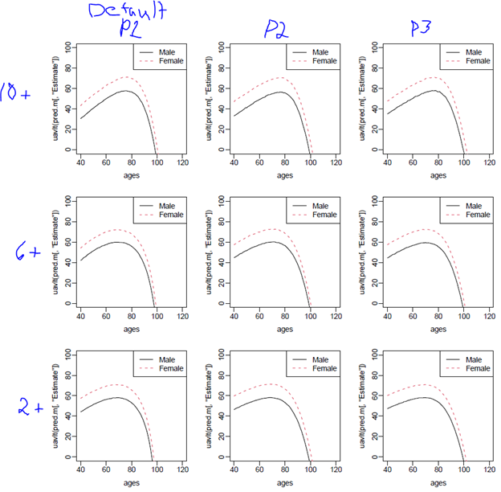

The overall shape varies by the data.

The convergence of the model (R-hats) varies by priors. The default prior performed terribly – it never converged in my tests. A minimum amount of user-specified prior was critical to get a decent model (e.g. specifying priors on Bs). Specifying priors on nearly all parameters had the best convergence, however with new data this may not be a great option if too constrained. So, if I want to get decent initial alpha values, then using a modicum of prior information on the Bs is important.

**Question**: If I use informative priors, do the VI models do OK?

**Answer**: Not for cognition

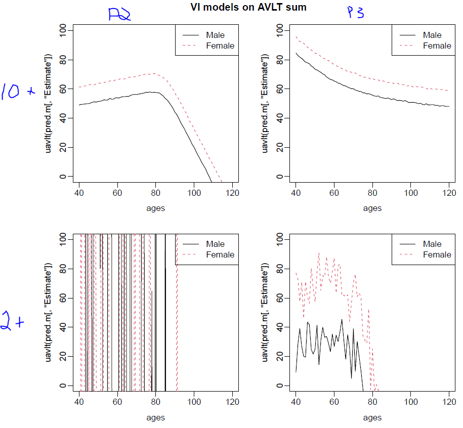

Only the one model reached a shape that made sense. VI models don’t produce meaningful R-hats so we can’t check ‘convergence’. The random effect standard deviation was OK in this model.

In conclusions, variational inference models that include two random effects:

- fail with less-informative subjects (e.g. 2+ fails more easily than 10+)
- fail with too few *or* too many user-specified priors
- require more iterations vs PET or plasma outcomes

Perhaps if you have the time to fiddle with it, we could get a reasonable model. However, it seems like going straight to MCMC is the most efficient approach for cognition or other outcomes like it with 2 types of random effects.

If we want to get initial values from a model that works and don’t have time to ‘fiddle’ with it, then use MCMC on cognition for initial values with at least a modicum of user-specified prior information, and subjects having 2+ measures.

# 10 Relative reproducibility

With the NLME method, we observed some outcomes were better suited than others. Less noisy outcomes converge to the same solution consistently, middling noisy outcomes would converge but not always to the same solution and some parameters would have large CIs. Care must be taken to include these outcomes (e.g. additional constraints may be needed.) Other outcomes were so noisy that were not well suited for modeling with the NLME method.

Investigate the relative signal to noise for each outcome.

Start by visually assessing trajectories for each of the outcomes. The purpose is to evaluate noise, and if there seems to be non-linearity over time.

There is a variation of these trajectory plots above, but only on a random sample of subjects having longer follow-ups. We may want to also review all trajectories among those have 3+ values.

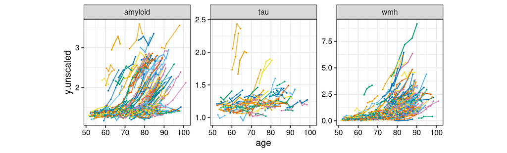

```r
pdat <- d %>%
  mutate(y.unscaled = case_when(
    npib < 3 & outcome == 'amyloid' ~ NA,
    ntau < 3 & outcome == 'tau' ~ NA,
    nwmh < 3 & outcome == 'wmh' ~ NA,
    TRUE ~ y.unscaled))

pdat %>%
  pfun2(., mapping=aes(x=age, y=y.unscaled)) +
  geom_point(size=0.2, aes(color=color)) +
  facet_wrap(~outcome, scales='free_y', ncol=3)
```

```r
fitlines <- function(id, time, y, howmany=4) {
#    cat("fitline ")   # it was so slow I thought it was broken
    keep1 <- !(is.na(time) | is.na(y))
    count <- table(id[keep1])
    uid <- names(count)[count >= howmany]
    nid <- length(uid)
    fits <- matrix(0, nid, 5)
    for (i in 1:nid) {
        tfit <- lm(y ~ time, subset= (id== uid[i]))
        sfit <- summary(tfit)
        fits[i,] <- c(coef(sfit)[c(1,2,4)], mean(predict(tfit)), sfit$sigma)
    }
    colnames(fits) <- c('intercept', 'slope', 'se(slope)', 'ybar', 'rss')
    list(fits=fits, id= uid, n= count[count >= howmany], count=table(count))
}

# this takes a long time to run, don't repeat when debugging
if (!exists("ds")) {
ds <- list(pib  = with(filter(d, outcome=='amyloid'), fitlines(id, age, y.unscaled)),
           lpib = with(filter(d, outcome=='amyloid'), fitlines(id, age, log(y.unscaled))),
           tau  = with(filter(d, outcome=='tau'),     fitlines(id, age, y.unscaled)),
           ltau = with(filter(d, outcome=='tau'),     fitlines(id, age, log(y.unscaled))),
           wmh  = with(filter(d, outcome=='wmh'),     fitlines(id, age, y.unscaled, 3)),
           sqrtwmh = with(filter(d, outcome=='wmh'),     fitlines(id, age, sqrt(y.unscaled), 3))
)}
```

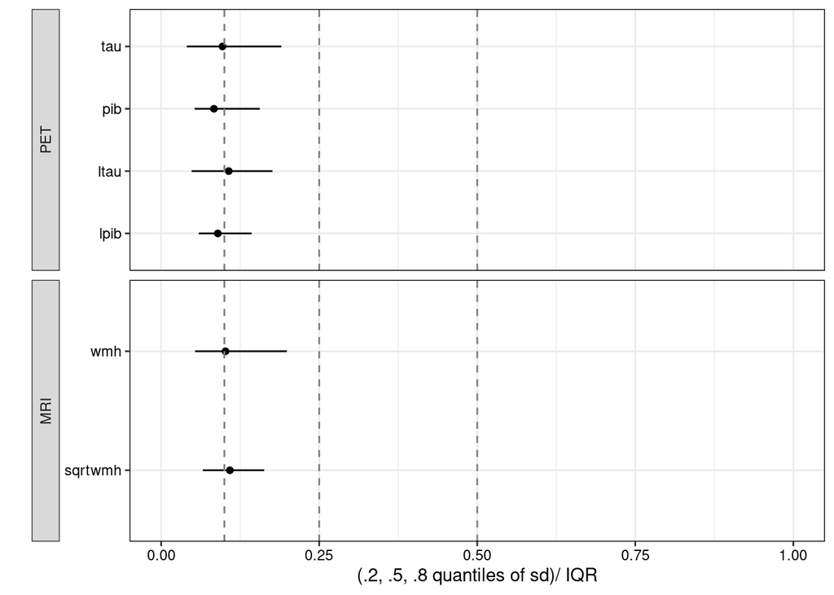

```r
cvs <- sapply(ds, function(x) {
    z <- x$fit
    quantile(z[,"rss"], c(.2, .5, .8))/ diff(quantile(z[,"ybar"], c(.25,.75)))
})

pdat <- t(cvs) %>%
  as.data.frame() %>%
  rownames_to_column('outcome') %>%
  mutate(gp1 = c(rep('PET',4),rep('MRI',2)),
         gp1 = factor(gp1, unique(gp1)))

pdat %>%
ggplot(., aes(x=`50%`,y=outcome,group=gp1)) +
  geom_point() +
  geom_segment(aes(x=`20%`, xend=`80%`,y=outcome,yend=outcome)) +
  geom_vline(xintercept=c(0.1,0.25,0.5),col='gray50',lty=2) +
  facet_wrap(~gp1, ncol=1, strip.position = 'left', scales = 'free_y') +
  xlim(0,1) +
  labs(x = "(.2, .5, .8 quantiles of sd)/ IQR",
       y = '') +
  theme(strip.placement='outside')
```

For the three outcomes we are including in these analyses, it appears that we should be OK. The relative reproducibility is reasonable.

Example figure legend: Longitudinal variability in measures quantified as the intra vs inter individual variability over serial measurements for a subset of MCSA participants. Each measure is scaled by the IQR. The value indicates how reliably we could determine if a given individual moved from the 25th to the 75th percentile of the response, i.e., how well we could detect if someone progressed.